# Anticoagulant Rodenticide Exposure in South Carolina Raptors

Patterns and Clinical Outcomes, 2024-2025

Author

Julian L. Costa

Published

October 4, 2025

## Data Coverage & Completeness

This dataset includes 48 raptors tested between 2024–2025.

- **Sampling**: Most (81%) of the submissions were from 2025 (39 of 48).
- **Species**: Great Horned Owls make up the majority (60%), followed by Red-tailed Hawks (23%). Other species were present in smaller numbers.
- **Completeness**: Key fields such as coordinates (98%), sex (83%), weight (83%), and clinical/necropsy notes (88–96%) are well recorded overall.
- **Age/Sex**: About half of birds had age noted, while sex was recorded in most cases. Only a few entries (4%) were flagged as “sex assumed.”
- **Rodenticide detection**: Nearly 90% of birds tested positive for at least one compound.

Table 1. Number of Raptors Sampled by Year

| year | Number of Samples |
| --- | --- |
| 2024 | 9 |
| 2025 | 39 |

Table 2. Distribution of Bird Species

| species_name | Count | % of Sample |
| --- | --- | --- |
| Great Horned Owl | 29 | 60.4 |
| Red-tailed Hawk | 11 | 22.9 |
| Barred Owl | 3 | 6.2 |
| Red-shouldered Hawk | 2 | 4.2 |
| Barn Owl | 1 | 2.1 |
| Osprey | 1 | 2.1 |
| Turkey Vulture | 1 | 2.1 |

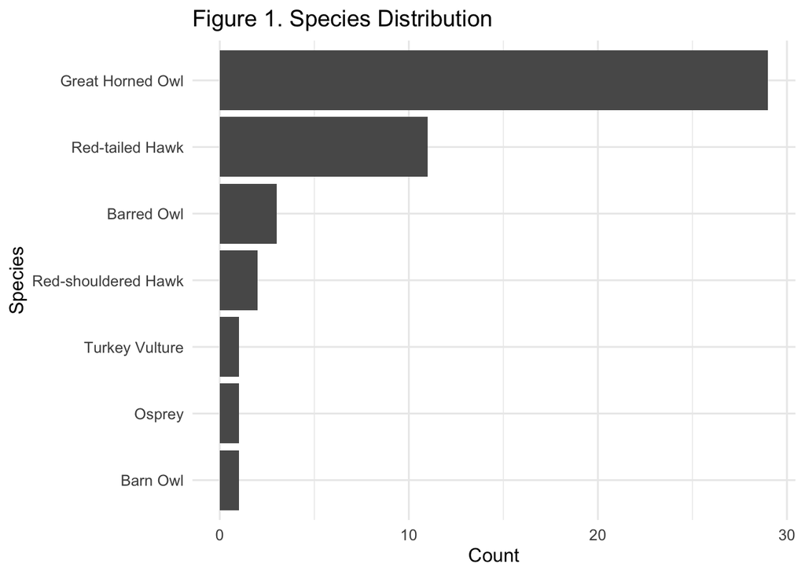

Table 3. Data Completeness by Key Field

| Field | Percent |
| --- | --- |
| With Coordinates | 97.9 |
| With Sex | 83.3 |
| Sex Assumed | 4.2 |
| With Weight | 83.3 |
| With Exam Notes | 95.8 |
| With Necropsy | 87.5 |

Table 4. Age/Sex Field Coverage

| Known Age (%) | Known Sex (%) | Sex Assumed (%) |
| --- | --- | --- |
| 54.2 | 83.3 | 4.2 |

Table 5. Age × Sex × Assumed Breakdown

| Age Class | Sex | Sex Assumed | Count |
| --- | --- | --- | --- |
| Adult | Male | FALSE | 11 |
| NA | Male | FALSE | 10 |
| Adult | Female | FALSE | 9 |
| NA | NA | FALSE | 7 |
| NA | Female | FALSE | 5 |
| Juvenile | Female | FALSE | 2 |
| Adult | Female | TRUE | 1 |
| Adult | Male | TRUE | 1 |
| Adult | NA | FALSE | 1 |
| Hatchling | Male | FALSE | 1 |

Table 6. Any Rodenticide Detected (Bird-level)

| Status | n | Percent |
| --- | --- | --- |
| No compounds detected | 5 | 10.4 |
| Detected ≥1 compound | 43 | 89.6 |

## Geography & Potential Hotspots

Admissions were mapped across South Carolina counties. Most admitted raptors came from coastal and more populated areas, while very few were admitted from upstate.

- **Multi-compound detections**: Found in both coastal and inland counties. Birds admitted from coastal areas were significantly more likely to show multiple compounds (Fisher’s Exact Test, p = 0.034, odds ratio ≈ 6.8). However, the confidence interval is wide, so this should be interpreted cautiously.
- **County-level view**: Coastal counties had more admitted birds overall.
- **Note**: Geographic results reflect where birds were admitted from, which may not match the actual exposure location. Patterns could also be influenced by factors such as human reporting or transport, not just where exposures occur.

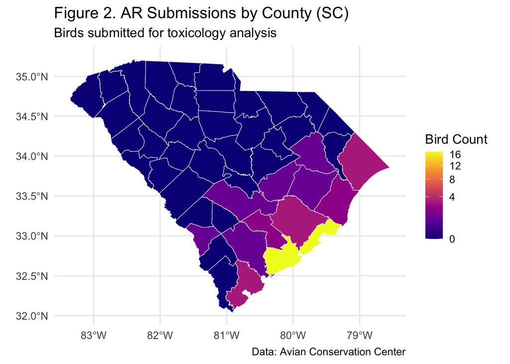

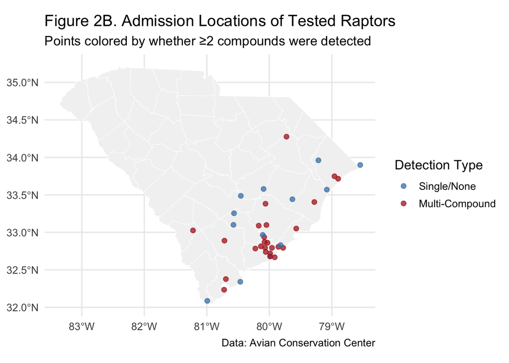

Table 7. Multi-Compound Detections by County

| County | Birds | Multi-Compound | Rate (%) |
| --- | --- | --- | --- |
| Allendale | 1 | 1 | 100.0 |
| Berkeley | 3 | 3 | 100.0 |
| Colleton | 1 | 1 | 100.0 |
| Florence | 1 | 1 | 100.0 |
| Charleston | 17 | 14 | 82.4 |
| Beaufort | 3 | 2 | 66.7 |
| Horry | 3 | 2 | 66.7 |
| Georgetown | 2 | 1 | 50.0 |
| Clarendon | 1 | 0 | 0.0 |
| Dorchester | 2 | 0 | 0.0 |
| Orangeburg | 1 | 0 | 0.0 |
| Williamsburg | 1 | 0 | 0.0 |
| NA | 2 | 0 | 0.0 |

Table 8. Multi-Compound Rate by Region (Coastal vs Non-coastal)

| Region | N | Rate (%) |
| --- | --- | --- |
| Coastal | 31 | 74.2 |
| Non-coastal | 7 | 28.6 |

```
    Fisher's Exact Test for Count Data

data:  coastal_mat
p-value = 0.03413
alternative hypothesis: true odds ratio is not equal to 1
95 percent confidence interval:
  0.8940933 84.1701147
sample estimates:
odds ratio
  6.757918
```

## Dose vs Clinical/Necropsy Findings

### Clinical Severity vs Dose

We compared rodenticide burden between birds with severe clinical findings and those with milder findings.

- **Mild/Other cases (n = 22)**: mean 1.47 ng/g, median 0.17, max 7.36 ng/g.
- **Severe cases (n = 24)**: mean 3.45 ng/g, median 0.60, max 23.5 ng/g.
- **Statistical test**: Wilcoxon rank-sum test → not significant (W = 243, p = 0.65).
- **Interpretation**: Severe cases tended to have higher burdens on average, but wide overlap suggests that dose alone does not predict severity.

Table 9. Total Dose (ng/g) by Clinical Severity

| exam_severity_level | n | mean_dose | median_dose | sd_dose | min_dose | max_dose |
| --- | --- | --- | --- | --- | --- | --- |
| Mild/Other | 22 | 1.47 | 0.17 | 2.10 | 0 | 7.36 |
| Severe | 24 | 3.45 | 0.60 | 6.04 | 0 | 23.52 |

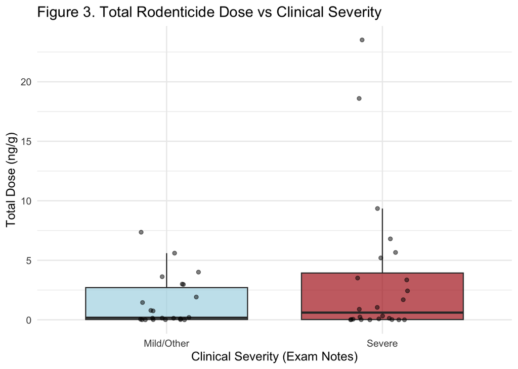

```
    Wilcoxon rank sum test with continuity correction

data:  total_dose_ng_g by exam_severity_level
W = 243, p-value = 0.652
alternative hypothesis: true location shift is not equal to 0
```

### Hemorrhage Necropsy Findings vs Dose

We compared rodenticide burden between birds with and without hemorrhage-related necropsy findings.

- **Hemorrhage absent (n = 15)**: mean 3.10 ng/g, median 0.14, max 23.5 ng/g.
- **Hemorrhage present (n = 27)**: mean 2.33 ng/g, median 0.89, max 18.6 ng/g.
- **Statistical test**: Wilcoxon rank-sum test → not significant (W = 174.5, p = 0.47).
- **Interpretation**: Birds with hemorrhage tended to have higher median rodenticide burdens, though those without hemorrhage included some of the highest observed outliers. Overall, the difference between groups was not statistically significant.

Table 10. Total Dose (ng/g) by Hemorrhage Necropsy Finding

| hemorrhage_flag | n | mean_dose | median_dose | sd_dose | min_dose | max_dose |
| --- | --- | --- | --- | --- | --- | --- |
| Hemorrhage: No | 15 | 3.10 | 0.14 | 6.23 | 0 | 23.52 |
| Hemorrhage: Yes | 27 | 2.33 | 0.89 | 3.87 | 0 | 18.60 |

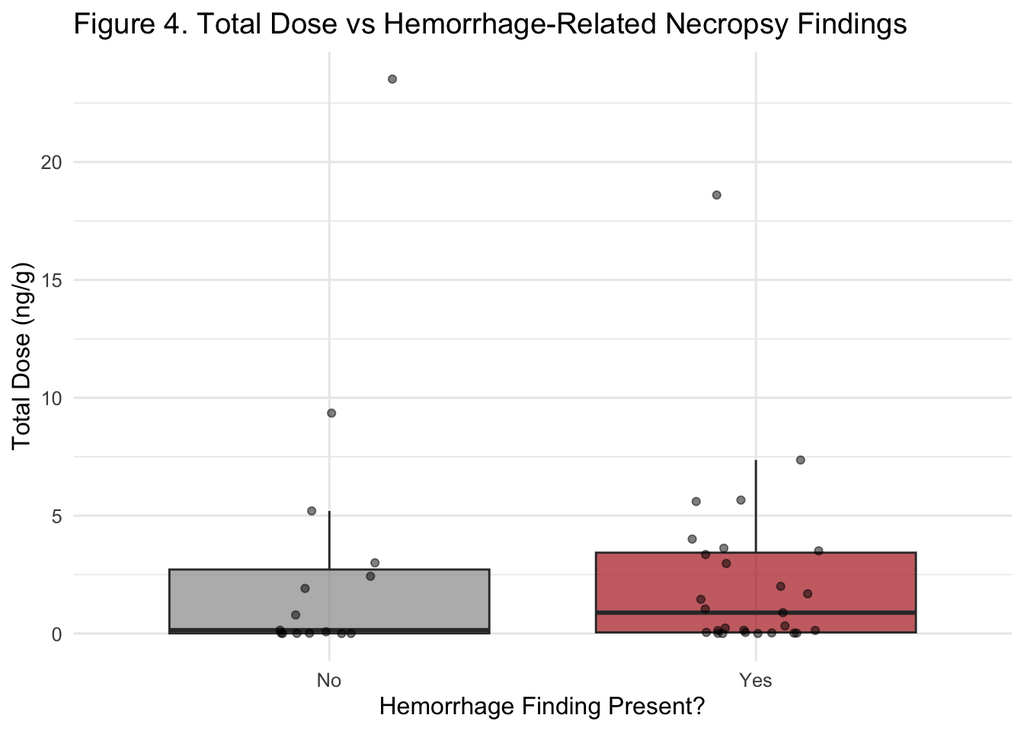

```
    Wilcoxon rank sum test with continuity correction

data:  total_dose_ng_g by hemorrhage_flag
W = 174.5, p-value = 0.4703
alternative hypothesis: true location shift is not equal to 0
```

### High-Dose Severe Cases

We reviewed the 10 highest-dose birds that were classified as severe cases. These admissions illustrate the clinical and necropsy signs most often associated with heavy rodenticide exposure.

- Doses ranged from 1.69 ng/g to 23.52 ng/g.
- Several birds showed classic coagulopathy signs (e.g., hemorrhage, shock, collapse).
- Multiple birds (n = 3) died within 24 hours of admission.
- Necropsy findings frequently documented hemorrhage, bruising, or organ damage.

Table 11. Highest-Dose Birds (Severe Cases)

| Year | Species | Total Dose (ng/g) | # Compounds | Weight (g) | Exam Notes | Necropsy Notes |
| --- | --- | --- | --- | --- | --- | --- |
| 2025 | Red-tailed Hawk | 23.5189 | 4 | 1200 | Coagulopathy; Weakness/collapsed chasing prey | Crop hemorrhage |
| 2024 | Great Horned Owl | 18.6000 | 3 | 1200 | Shock; Died within 24 hours; Laying prone | Blood unknown source |
| 2025 | Great Horned Owl | 9.3500 | 4 | 1492 | Shock; Soft tissue wounds | Bruising other |
| 2024 | Great Horned Owl | 6.8000 | 3 | 1046 | Bird on ground, unable to fly; Dehydration; Hypovolemic; Died within 24 hours; Shock | NA |
| 2025 | Red-tailed Hawk | 5.6600 | 2 | 1222 | Emaciated; No deep pain response | Bruising chest; Cholecystitis; Hemopneumopericardium / effusion / retrosternal hemothorax |
| 2024 | Red-tailed Hawk | 5.2000 | 2 | 1314 | Bird on ground, unable to fly; Lethargic; Suspect hit by car; Died in 4 days | Bruising abdomen; Crop hemorrhage |
| 2025 | Great Horned Owl | 3.5080 | 3 | 1041 | Died within 24 hours; Shock | Pericardial hemorrhage |
| 2025 | Red-tailed Hawk | 3.3500 | 3 | 1040 | Suspect hit by car; Hypovolemic; Eye hemorrhage | Bruising abdomen; Hemopneumopericardium / effusion / retrosternal hemothorax |
| 2025 | Great Horned Owl | 2.4293 | 2 | 1518 | Bird on ground, unable to fly; Pupillary hippus; Vent tonal laxity | Bruising chest; Hepatitis |
| 2025 | Great Horned Owl | 1.6860 | 3 | 1198 | Coagulopathy; Hypovolemic; Soft tissue wounds | Bruising abdomen; Hemoperitoneum; Hemopneumopericardium / effusion / retrosternal hemothorax; Pulmonary hemorrhage; Biliverdin jaundice |

## Weight vs Dose vs Symptoms

We looked at rodenticide dose relative to bird weight to see if smaller or larger raptors showed different vulnerability. By calculating a weight-adjusted dose (ng of toxin per gram of body weight), we highlight which birds carried disproportionately high toxic loads.

Table 12 lists the 10 birds with the highest weight-adjusted burdens. While most of these were large-bodied raptors, we note that one smaller Great Horned Owl (690 g) also appeared in the list.

Across these top cases, birds with the highest adjusted doses frequently showed severe clinical signs, including coagulopathy, collapse, hemorrhage, and in several instances, death within 24 hours.

Table 12. Highest Weight-Adjusted Dose Birds

| Year | Species | Total Dose (ng/g) | Weight (g) | Burden per Gram | Exam Notes | Necropsy Notes |
| --- | --- | --- | --- | --- | --- | --- |
| 2025 | Red-tailed Hawk | 23.5189 | 1200 | 0.0195991 | Coagulopathy; Weakness/collapsed chasing prey | Crop hemorrhage |
| 2024 | Great Horned Owl | 18.6000 | 1200 | 0.0155000 | Shock; Died within 24 hours; Laying prone | Blood unknown source |
| 2024 | Great Horned Owl | 6.8000 | 1046 | 0.0065010 | Bird on ground, unable to fly; Dehydration; Hypovolemic; Died within 24 hours; Shock | NA |
| 2025 | Great Horned Owl | 9.3500 | 1492 | 0.0062668 | Shock; Soft tissue wounds | Bruising other |
| 2025 | Great Horned Owl | 5.6000 | 1100 | 0.0050909 | Attacked by crows; Died within 24 hours | Bruising chest; Cholecystitis; Hemorrhagic gizzard; Hemopneumopericardium / effusion / retrosternal hemothorax |
| 2025 | Red-tailed Hawk | 5.6600 | 1222 | 0.0046318 | Emaciated; No deep pain response | Bruising chest; Cholecystitis; Hemopneumopericardium / effusion / retrosternal hemothorax |
| 2025 | Great Horned Owl | 3.0000 | 690 | 0.0043478 | Emaciated; Hypothermic; Bird on ground, unable to fly; Died within 24 hours | Bruising abdomen; Bruising other; Cholecystitis; Biliverdin jaundice |
| 2024 | Red-tailed Hawk | 5.2000 | 1314 | 0.0039574 | Bird on ground, unable to fly; Lethargic; Suspect hit by car; Died in 4 days | Bruising abdomen; Crop hemorrhage |
| 2025 | Great Horned Owl | 3.5080 | 1041 | 0.0033698 | Died within 24 hours; Shock | Pericardial hemorrhage |
| 2025 | Red-tailed Hawk | 3.3500 | 1040 | 0.0032212 | Suspect hit by car; Hypovolemic; Eye hemorrhage | Bruising abdomen; Hemopneumopericardium / effusion / retrosternal hemothorax |

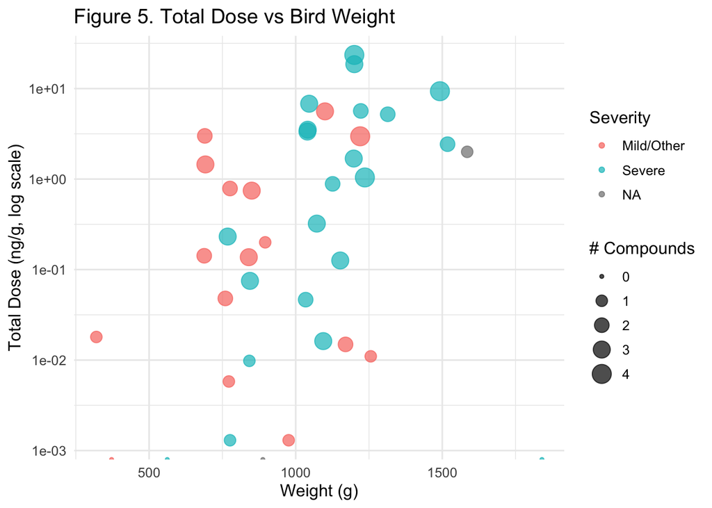

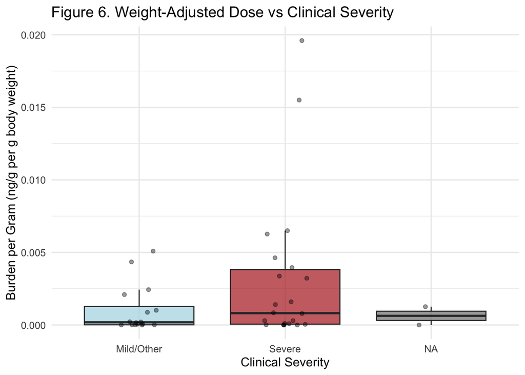

## Species vs Clinical/Necropsy Findings

Species-level patterns were summarized for admissions with adequate sample size (n ≥ 5). Among species with at least five birds, we report the percentage with **severe** clinical findings and the percentage with **hemorrhage** noted at necropsy.

Table 13. Species with ≥ 5 Admissions: % Severe and % Hemorrhage

| Species | N | Severe (n) | Severe (%) | Hemorrhage (n) | Hemorrhage (%) |
| --- | --- | --- | --- | --- | --- |
| Great Horned Owl | 29 | 14 | 48.3 | 16 | 55.2 |
| Red-tailed Hawk | 11 | 7 | 63.6 | 7 | 63.6 |

A Fisher’s Exact Test evaluated whether rates of severe findings differed by species.

### Clinical Severity vs Species

Fisher’s Exact Test showed no significant difference in the proportion of severe cases across species (p = 0.72), suggesting that no species clearly stood out as more likely to present with severe clinical signs.

- Odds ratio ≈ 1.6 (95% CI: 0.32–9.33).

```
    Fisher's Exact Test for Count Data

data:  sev_tab
p-value = 0.721
alternative hypothesis: true odds ratio is not equal to 1
95 percent confidence interval:
 0.3154699 9.3306068
sample estimates:
odds ratio
    1.6045
```

### Hemorrhage Findings vs Species

Fisher’s Exact Test showed no significant difference in hemorrhage-related necropsy findings across species (p = 1.00), indicating that hemorrhage findings were distributed fairly evenly across species.

- Odds ratio ≈ 1.16 (95% CI: 0.19–8.84).

```
    Fisher's Exact Test for Count Data

data:  hemo_tab
p-value = 1
alternative hypothesis: true odds ratio is not equal to 1
95 percent confidence interval:
 0.191881 8.844297
sample estimates:
odds ratio
  1.161448
```

## Sex vs Clinical/Necropsy Findings

We also tested whether clinical severity and hemorrhage at necropsy differ by sex.

- **Severe cases**: More common in females (71%) than males (39%). Fisher’s Exact Test gave p = 0.052. This is just above the standard 0.05 cutoff, suggesting a possible trend but not a statistically significant difference.
- **Hemorrhage findings**: Rates were similar between sexes (59% females vs 61% males), with no statistical difference (Fisher’s Exact Test, p = 1.00).

These results suggest that while there may be a tendency for females to present more often with severe findings, hemorrhage was equally observed in both sexes.

Table 14. Sex vs Clinical/Necropsy Findings (Known Sex Only)

| Sex | N | Severe (n) | Severe (%) | Hemorrhage (n) | Hemorrhage (%) |
| --- | --- | --- | --- | --- | --- |
| Male | 23 | 9 | 39.1 | 14 | 60.9 |
| Female | 17 | 12 | 70.6 | 10 | 58.8 |

[output not shown]

```
    Fisher's Exact Test for Count Data

data:  hemo_tab
p-value = 1
alternative hypothesis: true odds ratio is not equal to 1
95 percent confidence interval:
 0.1899573 4.9948515
sample estimates:
odds ratio
         1
```

## Compound-Specific Patterns

We examined which anticoagulant rodenticides (ARs) were most commonly detected across all raptor admissions.

- **Dominant compound**: Brodifacoum was the most common AR, detected in 81% of birds.
- **Other frequent SGARs**: Difethialone (54%) and bromodiolone (50%) were also widely present.
- **Less common SGARs**: Difenacoum was detected in 8% of birds.
- **FGARs**: Diphacinone was the only FGAR with notable detections (17%), while chlorophacinone appeared in just one bird (2%). Warfarin, coumachlor, coumatetralyl, and dicoumerol were not detected.
- **SGAR vs FGAR**: Nearly 88% of birds had at least one SGAR present, compared with only 19% showing any FGAR detection.

Table 15. Prevalence of Each Anticoagulant Rodenticide (AR) Across Birds

| Compound | Positive Birds | Prevalence (%) |
| --- | --- | --- |
| brodifacoum | 39 | 81.2 |
| difethialone | 26 | 54.2 |
| bromodiolone | 24 | 50.0 |
| diphacinone | 8 | 16.7 |
| difenacoum | 4 | 8.3 |
| chlorophacinone | 1 | 2.1 |
| coumachlor | 0 | 0.0 |
| coumatetralyl | 0 | 0.0 |
| dicoumerol | 0 | 0.0 |
| warfarin | 0 | 0.0 |

Table 16. SGAR vs FGAR Detection Prevalence

| SGAR Positive (n) | FGAR Positive (n) | SGAR (%) | FGAR (%) |
| --- | --- | --- | --- |
| 42 | 9 | 87.5 | 18.8 |

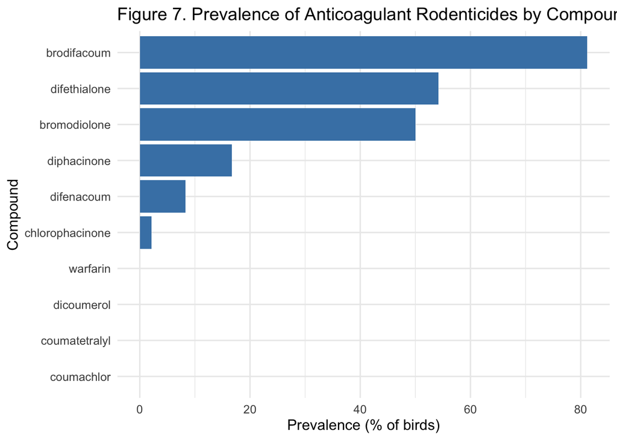

## Temporal Trends (2024 vs 2025)

We compared rodenticide detections across the two sampling years.

**Note**: The following tests focus on proportions (percentages of birds affected), not the absolute counts. While the total number of exposed birds was higher in 2025, the percentages were broadly similar year to year.

Table 17. Any Rodenticide Detected by Year

| Year | Status | n | Percent |
| --- | --- | --- | --- |
| 2024 | No compounds detected | 1 | 11.1 |
| 2024 | Detected ≥1 compound | 8 | 88.9 |
| 2025 | No compounds detected | 4 | 10.3 |
| 2025 | Detected ≥1 compound | 35 | 89.7 |

```
    Fisher's Exact Test for Count Data

data:  det_tab
p-value = 1
alternative hypothesis: true odds ratio is not equal to 1
95 percent confidence interval:
  0.0197686 13.2416549
sample estimates:
odds ratio
  1.091678
```

#### Findings

89% of birds in 2024 and 90% in 2025 tested positive for ≥1 compound. Fisher’s Exact Test showed no significant difference (p = 1.00).

Table 18. Multi-Compound Detections by Year

| Year | Status | n | Percent |
| --- | --- | --- | --- |
| 2024 | <2 Compounds | 2 | 22.2 |
| 2024 | ≥2 Compounds | 7 | 77.8 |
| 2025 | <2 Compounds | 14 | 35.9 |
| 2025 | ≥2 Compounds | 25 | 64.1 |

```
    Fisher's Exact Test for Count Data

data:  multi_tab
p-value = 0.6974
alternative hypothesis: true odds ratio is not equal to 1
95 percent confidence interval:
 0.04632991 3.24716877
sample estimates:
odds ratio
 0.5168614
```

#### Findings

78% of birds in 2024 and 64% in 2025 carried ≥2 compounds. Fisher’s Exact Test again showed no significant difference (p = 0.70).

### Compound-Specific Prevalence by Year

We compared detections of individual anticoagulant compounds between 2024 and 2025.

- The overall profile was consistent across both years, with SGARs (particularly brodifacoum, difethialone, and bromodiolone) dominating detections.
- FGARs remained rare, with only a few diphacinone detections and little change between years.

These results suggest that while the total number of admitted birds increased in 2025, the types of compounds driving exposure remained similar.

Table 19. Compound-Specific Prevalence by Year

| Compound | Positive_2024 | Positive_2025 | Prevalence_2024 | Prevalence_2025 |
| --- | --- | --- | --- | --- |
| brodifacoum | 8 | 31 | 88.9 | 79.5 |
| bromodiolone | 6 | 18 | 66.7 | 46.2 |
| chlorophacinone | 1 | 0 | 11.1 | 0.0 |
| coumachlor | 0 | 0 | 0.0 | 0.0 |
| coumatetralyl | 0 | 0 | 0.0 | 0.0 |
| dicoumerol | 0 | 0 | 0.0 | 0.0 |
| difenacoum | 0 | 4 | 0.0 | 10.3 |
| difethialone | 4 | 22 | 44.4 | 56.4 |
| diphacinone | 2 | 6 | 22.2 | 15.4 |
| warfarin | 0 | 0 | 0.0 | 0.0 |

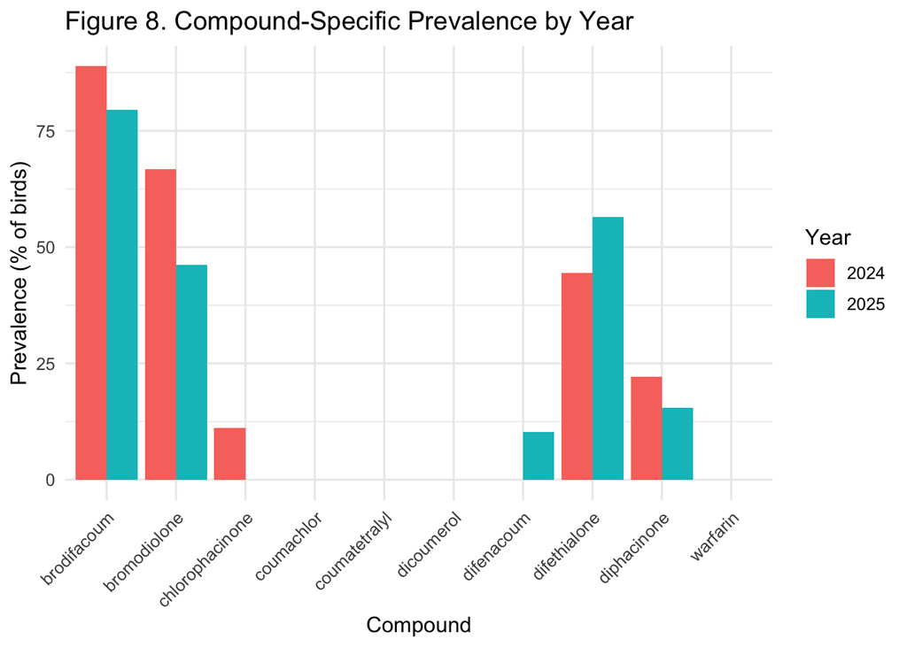

## Toxin Type vs Findings (SGAR/FGAR)

We tested whether the presence of any SGAR or FGAR was associated with clinical severity or hemorrhage.

### SGARs

Birds with ≥1 SGAR were somewhat less likely to be classified as severe (48% vs 67%), but this was not statistically significant (p = 0.35). Hemorrhage was more common when SGARs were present (62% vs 17%), but this also was not statistically significant (p = 0.12).

Table 20. Any SGAR Present vs Clinical/Necropsy Findings

| SGAR Present | N | Severe (n) | Severe (%) | Hemorrhage (n) | Hemorrhage (%) |
| --- | --- | --- | --- | --- | --- |
| No SGAR | 6 | 4 | 66.7 | 1 | 16.7 |
| Yes (≥1 SGAR) | 42 | 20 | 47.6 | 26 | 61.9 |

```
    Fisher's Exact Test for Count Data

data:  sev_sgar_tab
p-value = 0.3488
alternative hypothesis: true odds ratio is not equal to 1
95 percent confidence interval:
 0.004624645 2.756775534
sample estimates:
odds ratio
 0.2448678
```

```
    Fisher's Exact Test for Count Data

data:  hemo_sgar_tab
p-value = 0.122
alternative hypothesis: true odds ratio is not equal to 1
95 percent confidence interval:
   0.4452819 353.1803346
sample estimates:
odds ratio
  6.195002
```

### FGARs

Results were based on small numbers (n = 9 with any FGAR). Severe cases (44%) and hemorrhage (67%) were observed at similar rates to birds without FGARs, and no significant differences were found (p ≈ 0.7 for both tests).

Table 21. Any FGAR Present vs Clinical/Necropsy Findings (Sparse)

| FGAR Present | N | Severe (n) | Severe (%) | Hemorrhage (n) | Hemorrhage (%) |
| --- | --- | --- | --- | --- | --- |
| No FGAR | 39 | 20 | 51.3 | 21 | 53.8 |
| Yes (≥1 FGAR) | 9 | 4 | 44.4 | 6 | 66.7 |

```
    Fisher's Exact Test for Count Data

data:  sev_fgar_tab
p-value = 0.7178
alternative hypothesis: true odds ratio is not equal to 1
95 percent confidence interval:
 0.1160849 3.7642992
sample estimates:
odds ratio
 0.6857591
```

```
    Fisher's Exact Test for Count Data

data:  hemo_fgar_tab
p-value = 0.6888
alternative hypothesis: true odds ratio is not equal to 1
95 percent confidence interval:
  0.2712776 21.2100202
sample estimates:
odds ratio
  1.831581
```

Overall, SGAR exposures were more frequent and showed a tendency toward higher hemorrhage rates, but neither SGAR nor FGAR presence was significantly linked to severity or hemorrhage in this sample.

## Summary & Conclusions

This analysis examined anticoagulant rodenticide (AR) exposure patterns in 48 South Carolina raptors based on toxicology testing coordinated by the Avian Conservation Center (Awendaw, SC) during 2024-2025.

### Recommendations for Future Work

- **Expand sample size and diversity:** Increasing the number of admissions tested, and including a wider variety of species, would strengthen analyses and improve statistical power.
- **Integrate ecological context:** Combine toxicology results with prey availability, land use, and rodenticide application data to better understand exposure pathways.
- **Collaborative expansion:** Partner with wildlife centers across the Southeast to broaden data collection and generate more robust regional assessments.

While these findings mark important progress in understanding rodenticide exposure, they also underscore the need for continued awareness and expanded research to protect raptor populations into the future.